# PROYECTO FINAL

Rosaisela Perez

2025-07-31

## Justificación

En este análisis se examina la calidad del aire en diversos municipios de Puebla durante el año 2018 y si existe una posible relación con los incendios forestales registrados en ese periodo. Se busca identificar patrones de contaminación atmosférica para poder hacer la evaluación de alternativas.

## *ETAPA 1: Configuración y Adquisición de Datos*

```r
#Cargar librerías necesarias
library(readr)
library(here)
library(dplyr)
library(stringr)
library(janitor)
library(ggplot2)
library(factoextra)
```

*Ingesta de datos*

```r
#lectura directa desde URL
calidad_aire<- read.csv("https://www.datos.gob.mx/dataset/bd428f6b-bc9a-4617-8c4b-9dd320101f30/resource/70dfeb69-065b-4ed4-8922-505602666250/download/d3_aire01_49_1.csv")
```

Documentación:

Origen: Plataforma Nacional de datos Abiertos (Mexico)

URL: https://datos.gob.mx/dataset/calidad_aire_emisiones_contaminantes/resource/70dfeb69-065b-4ed4-8922-505602666250

Fecha descarga: 23/07/2025

Delimitador “,”

Codificación UTF-8

Relevancia: En un contexto donde la calidad del aire empeora en todos los Estados del País, conocer las principales fuentes de emisión así como los contaminantes principales nos podrían dar ideas para la mitigación de ellos.

NOTA: Es el inventario del año 2018

```r
#Lectura local
incendios<- read_csv(here("data", "raw", "incendios.csv"))
```

Documentación

Origen: Plataforma Nacional de datos Abiertos (Mexico)

URL: https://datos.gob.mx/dataset/incendios_forestales

Fecha descarga: 23/07/2025

Método lectura: read_csv

Delimitador: “,”

Codificación UTF-8

Relevancia: Acorde al set de datos de la URL que nos muestra las fuentes de contaminación por entidad así como los tipos de contaminantes el conocer si existe una relación significativa entre la contaminación atmosférica y los incendios forestales, siendo estos últimos un problema que ultimamente afecta a un volcán muy importante en mi Estado.

## *ETAPA 2: Limpieza y estandarización*

```r
#observamos rápidamente los datos
str(calidad_aire)
```

```
## 'data.frame':    10521 obs. of  11 variables:
##  $ Entidad_federativa: chr  "Aguascalientes" "Aguascalientes" "Aguascalientes" "Aguascalientes" ...
##  $ Municipio         : chr  "Aguascalientes" "Aguascalientes" "Aguascalientes" "Aguascalientes" ...
##  $ Tipo_de_Fuente    : chr  "Fuentes fijas" "Fuentes de área" "Fuentes móviles carreteros" "Fuentes móviles que no circulan por carretera" ...
##  $ SO_2              : num  546.3 15.9 308 37 NA ...
##  $ CO                : num  94.3 2396.3 48527.1 548.8 NA ...
##  $ NOx               : num  209 333 10487 1042 440 ...
##  $ COV               : num  2219.4 12438.8 5149 96.9 1663.8 ...
##  $ PM_010            : num  246.9 1567 721.4 66.3 NA ...
##  $ PM_2_5            : num  182.1 483.1 659.9 63.9 NA ...
##  $ NH_3              : num  2.93 1.37e+04 8.39e+01 2.26e-01 NA ...
##  $ Entidad           : chr  "Aguascalientes" "Aguascalientes" "Aguascalientes" "Aguascalientes" ...
```

```r
#Ya que existen 11 columnas. Debemos seleccionar unicamente las relevantes para el estudio
calidad_aire<- select(calidad_aire, Entidad, Municipio, Tipo_de_Fuente,PM_2_5,CO,SO_2,NOx)

str(calidad_aire)
```

```
## 'data.frame':    10521 obs. of  7 variables:
##  $ Entidad       : chr  "Aguascalientes" "Aguascalientes" "Aguascalientes" "Aguascalientes" ...
##  $ Municipio     : chr  "Aguascalientes" "Aguascalientes" "Aguascalientes" "Aguascalientes" ...
##  $ Tipo_de_Fuente: chr  "Fuentes fijas" "Fuentes de área" "Fuentes móviles carreteros" "Fuentes móviles que no circulan por carretera" ...
##  $ PM_2_5        : num  182.1 483.1 659.9 63.9 NA ...
##  $ CO            : num  94.3 2396.3 48527.1 548.8 NA ...
##  $ SO_2          : num  546.3 15.9 308 37 NA ...
##  $ NOx           : num  209 333 10487 1042 440 ...
```

```r
summary(calidad_aire)
```

```
##    Entidad           Municipio         Tipo_de_Fuente         PM_2_5
##  Length:10521       Length:10521       Length:10521       Min.   :   0.000
##  Class :character   Class :character   Class :character   1st Qu.:   0.303
##  Mode  :character   Mode  :character   Mode  :character   Median :   4.351
##                                                           Mean   :  70.793
##                                                           3rd Qu.:  38.406
##                                                           Max.   :9112.430
##                                                           NA's   :2453
##        CO                SO_2                NOx
##  Min.   :    0.00   Min.   :     0.00   Min.   :    0.00
##  1st Qu.:    3.49   1st Qu.:     0.14   1st Qu.:    5.29
##  Median :   84.12   Median :     0.77   Median :   38.72
##  Mean   :  979.17   Mean   :   167.18   Mean   :  301.86
##  3rd Qu.:  584.40   3rd Qu.:     3.69   3rd Qu.:  194.40
##  Max.   :95906.72   Max.   :202344.33   Max.   :72682.61
##  NA's   :2453       NA's   :2453
```

```r
#Selección de columnas de interés
incendios<- select(incendios, Entidad, Municipio, Causa,Total_hectareas, Fecha_Termino)
str(incendios)
```

```
## tibble [71,089 × 5] (S3: tbl_df/tbl/data.frame)
##  $ Entidad        : chr [1:71089] "Aguascalientes" "Aguascalientes" "Aguascalientes" "Aguascalientes" ...
##  $ Municipio      : chr [1:71089] "Calvillo" "Aguascalientes" "Aguascalientes" "Rincón de Romos" ...
##  $ Causa          : chr [1:71089] "Fogatas" "Intencional" "Intencional" "Intencional" ...
##  $ Total_hectareas: num [1:71089] 2.29 72.66 14.94 1.52 31.83 ...
##  $ Fecha_Termino  : Date[1:71089], format: "2015-01-05" "2015-01-14" ...
```

```r
summary(incendios)
```

```
##    Entidad           Municipio            Causa           Total_hectareas
##  Length:71089       Length:71089       Length:71089       Min.   :    0.00
##  Class :character   Class :character   Class :character   1st Qu.:    1.50
##  Mode  :character   Mode  :character   Mode  :character   Median :    5.00
##                                                           Mean   :   94.31
##                                                           3rd Qu.:   26.50
##                                                           Max.   :35540.82
##  Fecha_Termino
##  Min.   :2015-01-01
##  1st Qu.:2017-04-25
##  Median :2020-01-12
##  Mean   :2019-12-09
##  3rd Qu.:2022-05-07
##  Max.   :2024-12-31
```

```r
#Estudio únicamente del Estado de Puebla
calidad_aire<- filter(calidad_aire, Entidad== "Puebla")

incendios<- filter(incendios, Entidad=="Puebla")

#Detección y eliminación de Duplicados
sum(duplicated(calidad_aire))
```

```
## [1] 0
```

```r
calidad_aire<- calidad_aire[!duplicated(calidad_aire), ]

sum(duplicated(calidad_aire)) #rectificar eliminación de duplicados.
```

```
## [1] 0
```

```r
sum(duplicated(incendios))
```

```
## [1] 17
```

```r
incendios<- incendios[!duplicated(incendios), ]

sum(duplicated(incendios)) #rectificar la eliminación de duplicados.
```

```
## [1] 0
```

```r
#Oservar cuántos datos Nulos tenemos por columna
summarise_all(calidad_aire, funs(sum(is.na(.))))
```

```
##   Entidad Municipio Tipo_de_Fuente PM_2_5  CO SO_2 NOx
## 1       0         0              0    217 217  217   0
```

```r
#Eliminar los datos nulos.
calidad_aire<- na.omit(calidad_aire)
summarise_all(calidad_aire, funs(sum(is.na(.))))
```

```
##   Entidad Municipio Tipo_de_Fuente PM_2_5 CO SO_2 NOx
## 1       0         0              0      0  0    0   0
```

```r
summarise_all(incendios, funs(sum(is.na(.)))) #No existen datos Nulos.
```

```
## # A tibble: 1 × 5
##   Entidad Municipio Causa Total_hectareas Fecha_Termino
##     <int>     <int> <int>           <int>         <int>
## 1       0         0     0               0             0
```

```r
#Estandarizar nombres de columnas
incendios<-janitor::clean_names(incendios)

calidad_aire<- janitor::clean_names(calidad_aire)
colnames(calidad_aire)
```

```
## [1] "entidad"        "municipio"      "tipo_de_fuente" "pm_2_5"
## [5] "co"             "so_2"           "n_ox"
```

```r
#Debido a que 2 columnas
#mantienen nombres dificies se hará un rename

calidad_aire<-calidad_aire%>%
  rename(pm_25 = pm_2_5)

calidad_aire<-calidad_aire%>%
  rename(nox =n_ox)

calidad_aire<-calidad_aire%>%
  rename(so2 =so_2)

colnames(calidad_aire)
```

```
## [1] "entidad"        "municipio"      "tipo_de_fuente" "pm_25"
## [5] "co"             "so2"            "nox"
```

```r
#rectificar formato de fechas


incendios<- incendios%>%
  mutate(fecha_termino=as.Date(fecha_termino, format("%Y-%m-%d"))
  )

head(incendios$fecha_termino)
```

```
## [1] "2015-01-13" "2015-01-14" "2015-01-16" "2015-01-17" "2015-01-17"
## [6] "2015-01-18"
```

```r
#Guardar datos limpios
#write.csv(incendios,"data/processed/clean_incendios.csv",row.names = FALSE)
#write.csv(calidad_aire,"data/processed/clean_calidad_aire.csv",row.names = FALSE)
```

## *ETAPA 3: Transformación y Unificación*

```r
#Selección de municipios de ESTUDIO

incendios <- incendios %>%
  filter(municipio %in% c("Puebla", "Atlixco", "San Pedro Cholula", "Libres", "Acajete", "Zacatlán", "Amozoc", "Huejotzingo" ))
incendios
```

```
## # A tibble: 571 × 5
##    entidad municipio         causa                 total_hectareas fecha_termino
##    <chr>   <chr>             <chr>                           <dbl> <date>
##  1 Puebla  Libres            Intencional                      1    2015-01-19
##  2 Puebla  Puebla            Actividades agropecu…            1    2015-02-03
##  3 Puebla  San Pedro Cholula Fogatas                          2    2015-02-15
##  4 Puebla  Atlixco           Fumadores                        1    2015-02-22
##  5 Puebla  Atlixco           Intencional                     10    2015-02-23
##  6 Puebla  Zacatlán          Otras causas                     6    2015-02-24
##  7 Puebla  San Pedro Cholula Fogatas                          1    2015-02-24
##  8 Puebla  Puebla            Actividades agropecu…            0.5  2015-02-25
##  9 Puebla  Zacatlán          Actividades agropecu…            1    2015-02-26
## 10 Puebla  Puebla            Actividades agropecu…            0.75 2015-02-26
## # ℹ 561 more rows
```

```r
#Selección de municipios de ESTUDIO
calidad_aire<- calidad_aire%>%
  filter(municipio %in% c("Puebla", "Atlixco", "San Pedro Cholula", "Libres", "Acajete","Zacatlán", "Amozoc", "Huejotzingo"))
calidad_aire
```

```
##    entidad         municipio                                tipo_de_fuente
## 1   Puebla           Acajete                                 Fuentes fijas
## 2   Puebla           Acajete                               Fuentes de área
## 3   Puebla           Acajete                    Fuentes móviles carreteros
## 4   Puebla           Acajete Fuentes móviles que no circulan por carretera
## 5   Puebla            Amozoc                                 Fuentes fijas
## 6   Puebla            Amozoc                               Fuentes de área
## 7   Puebla            Amozoc                    Fuentes móviles carreteros
## 8   Puebla            Amozoc Fuentes móviles que no circulan por carretera
## 9   Puebla           Atlixco                                 Fuentes fijas
## 10  Puebla           Atlixco                               Fuentes de área
## 11  Puebla           Atlixco                    Fuentes móviles carreteros
## 12  Puebla           Atlixco Fuentes móviles que no circulan por carretera
## 13  Puebla       Huejotzingo                                 Fuentes fijas
## 14  Puebla       Huejotzingo                               Fuentes de área
```

[output cut: 47 more lines]

```r
#selección del año de estudio (2018) en el DS "incendios"
incendios <- incendios %>%
  filter(format(fecha_termino, "%Y") == "2018")
incendios
```

```
## # A tibble: 66 × 5
##    entidad municipio causa                 total_hectareas fecha_termino
##    <chr>   <chr>     <chr>                           <dbl> <date>
##  1 Puebla  Puebla    Fogatas                           3   2018-01-06
##  2 Puebla  Puebla    Intencional                       2   2018-01-08
##  3 Puebla  Acajete   Intencional                       1.5 2018-01-09
##  4 Puebla  Puebla    Fogatas                          25   2018-01-13
##  5 Puebla  Libres    Actividades agrícolas             1   2018-01-17
##  6 Puebla  Atlixco   Fogatas                           2   2018-01-20
##  7 Puebla  Libres    Actividades agrícolas             2   2018-01-20
##  8 Puebla  Acajete   Intencional                       1   2018-01-21
##  9 Puebla  Puebla    Actividades agrícolas             3   2018-01-21
## 10 Puebla  Libres    Intencional                       3   2018-01-21
## # ℹ 56 more rows
```

```r
#La "repetición" de municipios es debido a que
#en cada municipio existe un tipo de fuente, vamos a considerar
#las lecturas de los contaminantes en forma general (sin clasificar por tipo de fuente

calidad_aire <- calidad_aire %>%
  select(-tipo_de_fuente) %>%  # Eliminar columna que no se usará
  group_by(municipio) %>%
  summarise(
    pm_25 = mean(pm_25),
    co    = mean(co),
    so2   = mean(so2),
    nox   = mean(nox),
    .groups = "drop"
  )
```

Realizamos una gráfica de las causas de los incendios forestales por municipio de estudio.

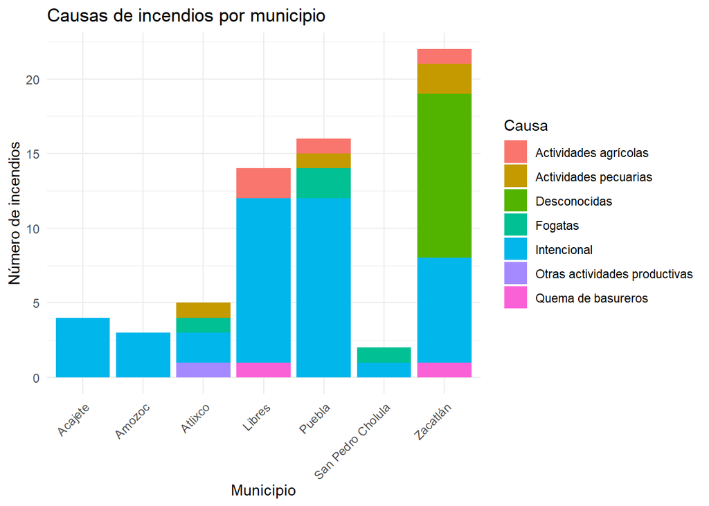

```r
#graficar causas
conteo <- incendios %>%
  group_by(municipio, causa) %>%
  summarise(n = n(), .groups = "drop")

ggplot(conteo, aes(x = municipio, y = n, fill = causa)) +
  geom_bar(stat = "identity") +
  labs(title = "Causas de incendios por municipio",
       x = "Municipio",
       y = "Número de incendios",
       fill = "Causa") +
  theme_minimal() +
  theme(axis.text.x = element_text(angle = 45, hjust = 1))
```

Podemos observar que en el municipio de Puebla, y en varios otros, la mayor causa de incendios forestales son “intencionales”.

Realizamos un segundo gráfico que nos ayude a ver el número de hectáreas perdidas a causa de incendios forestales por cada municipio de estudio:

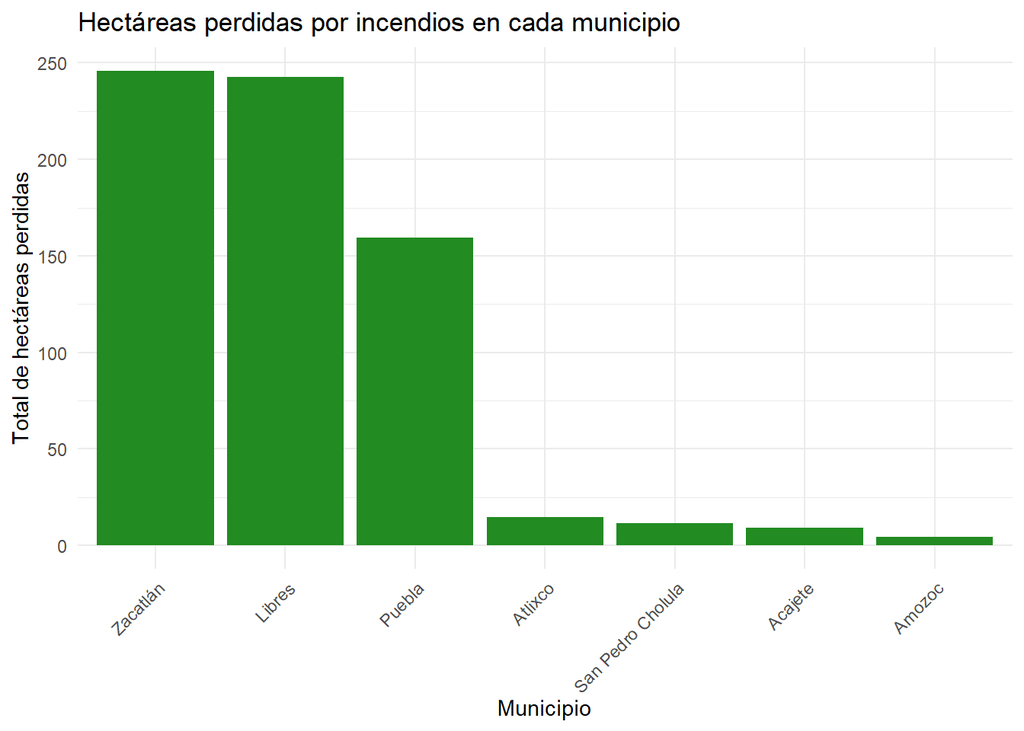

```r
#Sumar las hectáreas perdidas por municipio
hectareas_municipio <- incendios %>%
  group_by(municipio) %>%
  summarise(total_hectareas = sum(total_hectareas, na.rm = TRUE)) %>%
  arrange(desc(total_hectareas))  # Para ordenar de mayor a menor

# Grafico de barras
ggplot(hectareas_municipio, aes(x = reorder(municipio, -total_hectareas), y = total_hectareas)) +
  geom_bar(stat = "identity", fill = "forestgreen") +
  labs(title = "Hectáreas perdidas por incendios en cada municipio",
       x = "Municipio",
       y = "Total de hectáreas perdidas") +
  theme_minimal() +
  theme(axis.text.x = element_text(angle = 45, hjust = 1))
```

```r
incendios<- incendios %>%
  select( -fecha_termino) %>%
  group_by(municipio) %>%
  summarise(
    total_hectareas= mean(total_hectareas, na.rm = TRUE),
    .groups = "drop"
  )
```

Con éste podemos observar que el municipio de Puebla se encuentra dentro de los tres municipios con mayor cantidad de hectáreas perdidas por incendios forestales con poco más de 150 hectáreas. El municipio de Zacatlán y de Libres encabezan la gráfica sinembargo, considerando que las áreas verdes con las que cuenta el municipio de puebla son menores a las de los otros dos municipios se concluye que es una cifra alarmante.

```r
#Unimos los datos de ambos datasets
Data<- full_join(incendios, calidad_aire, by="municipio")

Data
```

```
## # A tibble: 8 × 6
##   municipio         total_hectareas pm_25     co    so2   nox
##   <chr>                       <dbl> <dbl>  <dbl>  <dbl> <dbl>
## 1 Acajete                      2.29  42.0   696. 611.    242.
## 2 Amozoc                       1.5   38.7   687.  16.6   192.
## 3 Atlixco                      2.91  71.2  2147.  11.2   385.
## 4 Libres                      17.3   40.2   587.   3.86  116.
## 5 Puebla                       9.97 450.  21972. 269.   5176.
## 6 San Pedro Cholula            5.75 808.   3484.  26.5   484.
## 7 Zacatlán                    11.2  111.   1370.   9.81  264.
## 8 Huejotzingo                 NA     45.4   862.  49.1   990.
```

```r
#Guardamos el nuevo dataset limpio y unificado
#write.csv(Data,"/data/processed/final_dataset.csv",row.names = FALSE)
```

## *ETAPA 4: Análisis exploratorio y entrega final*

```r
#Aplicación de un PCA
# Preparamos los datos excluyendo el nombre del municipio
datos_pca <- Data %>%
  select(-municipio) %>%
  na.omit()
datos_pca
```

```
## # A tibble: 7 × 5
##   total_hectareas pm_25     co    so2   nox
##             <dbl> <dbl>  <dbl>  <dbl> <dbl>
## 1            2.29  42.0   696. 611.    242.
## 2            1.5   38.7   687.  16.6   192.
## 3            2.91  71.2  2147.  11.2   385.
## 4           17.3   40.2   587.   3.86  116.
## 5            9.97 450.  21972. 269.   5176.
## 6            5.75 808.   3484.  26.5   484.
## 7           11.2  111.   1370.   9.81  264.
```

```r
#Aplicamos PCA
pca_result <- prcomp(datos_pca, scale. = TRUE)

#Ver resumen
summary(pca_result)
```

```
## Importance of components:
##                           PC1    PC2    PC3    PC4     PC5
## Standard deviation     1.5300 1.1477 0.9477 0.6660 0.01609
## Proportion of Variance 0.4682 0.2635 0.1796 0.0887 0.00005
## Cumulative Proportion  0.4682 0.7316 0.9113 1.0000 1.00000
```

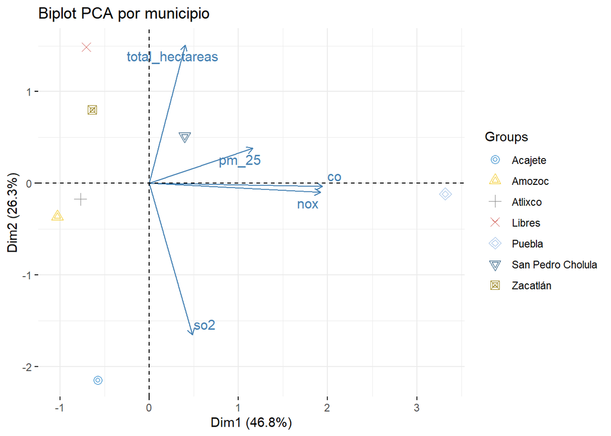

```r
# Graficar componentes
 fviz_pca_biplot(pca_result,
                label = "var",
                habillage = Data$municipio[complete.cases(Data %>% select(-municipio))],
                palette = "jco",
                repel = TRUE,
                title = "Biplot PCA por municipio")
```

Se realizó un biplot utilizando el Análisis de Componentes Principales (PCA) con el objetivo de explorar si existe alguna relación entre la calidad del aire (considerando contaminantes como PM2.5, CO, SO₂ y NOₓ) y la superficie afectada por incendios forestales en distintos municipios del estado de Puebla.

En el gráfico generado:

1.- Cada punto representa un municipio.

2.- Las flechas indican la influencia de cada variable (contaminantes e incendios) sobre los municipios.

3.- Los contaminantes PM2.5, CO y NOₓ están relacionados entre sí, lo que indica que cuando uno aumenta, los otros también tienden a hacerlo.

## *Conclusión*

Con base en el análisis de componentes principales (PCA), no se observa una relación directa entre la superficie afectada por incendios forestales y los niveles de contaminantes atmosféricos en los municipios analizados.